# HC2 Validation: Coverage Under Heteroskedasticity

Quantitative Methods

2026-02-16

# 1 Purpose

This notebook is **Part 2 – Apply HC2 to heteroskedastic data and develop an N-invariant severity measure**.

Part 1 established a baseline: how the inferential score behaves when data is perfectly specified (homoskedastic). Now we ask: what happens when heteroskedasticity violates that assumption? The workflow:

1. Use the HC2 estimator selected in Part 1
2. Simulate regression data with *intentional* heteroskedasticity at varying strengths
3. Demonstrate that the raw inferential score scales with sample size (it’s a test statistic, not a severity measure)
4. Develop an N-invariant alternative: the **reliability score** that measures heteroskedasticity severity independent of sample size
5. Validate the reliability score’s N-invariance properties
6. Analyze coverage degradation under heteroskedasticity

# 2 Section 1: Setup and Load Notebook 1 Results

## 2.1 Load Support Functions and Configuration

## 2.2 Load Results from Null Calibration

```r
# Retrieve HC type selected in null calibration
best_hc <- readRDS("results/best_hc.rds")
scaling_results <- readRDS("results/scaling_results.rds")

cat(sprintf("Selected HC estimator: %s\n", best_hc))
cat(sprintf("Stability range at optimal scaling: %.6f\n\n",
            scaling_results[hc_type == best_hc, stability_range_inf]))
```

Output: reports the selected HC estimator and its stability range from Part 1.

# 3 Section 2: The Heteroskedastic Test Case

We now introduce heteroskedasticity intentionally in the data generating process. The regression model is:
$$Y_i = 1 + \beta_x \cdot X_i +
\varepsilon_i$$
where the error variance depends on $X_i$:
$$\text{Var}(\varepsilon_i) = \sigma_0^2 + \lambda
\cdot X_i^2$$

Parameters we vary: - **$\beta_x$**: effect size (strength of $X$ in predicting $Y$) - **$\sigma_0$**: baseline noise (homoskedastic component) - **$\lambda$**: heteroskedasticity strength (controls how variance depends on $X$) - **$N$**: sample size

We will test all combinations to see how HC2 handles different severities of misspecification.

```r
# Simulation grid: sample sizes, heteroskedasticity strengths, and replicates per cell
# Note: These are defined in R/00_config.R and loaded automatically.
# We display them here for confirmation.

total_hetero <- length(N_GRID_HETERO) *
                length(HETERO_STRENGTH_GRID) *
                length(BETA_X_GRID) *
                length(SIGMA0_GRID) *
                N_SIMS_PER_CELL_HETERO

cat(sprintf("Simulation grid configuration:\n"))
cat(sprintf("  Sample sizes (N):           %s\n", paste(N_GRID_HETERO, collapse = ", ")))
cat(sprintf("  Hetero strength (λ):        %d levels from %.1f to %.1f\n",
            length(HETERO_STRENGTH_GRID), min(HETERO_STRENGTH_GRID), max(HETERO_STRENGTH_GRID)))
cat(sprintf("  Beta X values:              %s\n", paste(BETA_X_GRID, collapse = ", ")))
cat(sprintf("  Sigma0 values:              %s\n", paste(SIGMA0_GRID, collapse = ", ")))
cat(sprintf("  Replicates per cell:        %d\n", N_SIMS_PER_CELL_HETERO))
cat(sprintf("  Total simulations:          %d\n", total_hetero))
cat(sprintf("  HC estimator:               %s\n\n", best_hc))
```

Output: prints the full simulation grid configuration for transparency.

# 4 Section 3: Heteroskedastic Simulation and Metrics

Execute the full heteroskedastic simulation grid. For each cell (N, λ, β, σ0), generate replicates, compute 95% confidence intervals using both classical and HC standard errors, and record coverage outcomes.

The simulation engine `run_hetero_sim_grid` (in `R/40_hetero_sims.R`) computes: - `sr_inf`: Inferential Score $S_{\mathrm{Inf}} = \text{SE}_{\text{robust}}/\text{SE}_{\text{classic}} - 1$ - `sr_inf_adj`: Scaled Inferential Score $S_{\mathrm{Inf}}^{*} = \sqrt{N} \cdot S_{\mathrm{Inf}}$ - `coverage`: Classical CI coverage (using $\text{SE}_{\text{classic}}$)

**Note:** Ratio-based metrics ($S_{\mathrm{Rel}}$) are computed post-hoc in Section 5 after establishing the N-dependence problem.

```r
# Note: Random seed already set in R/00_config.R and propagated to parallel workers
# via furrr_options(seed = TRUE) for full reproducibility

hetero_sim_results <- run_hetero_sim_grid(
  N_grid = N_GRID_HETERO,
  hetero_strength_grid = HETERO_STRENGTH_GRID,
  beta_x_grid = BETA_X_GRID,
  sigma0_grid = SIGMA0_GRID,
  n_sims_per_cell = N_SIMS_PER_CELL_HETERO,
  hc_type = best_hc,
  verbose = TRUE
)
```

```
## Running heteroskedastic simulation grid:
##   N values: 50, 100, 200, 400, 800, 1600
##   Hetero strengths: 0 to 2
##   Beta X values: 0.2, 0.5, 0.8
##   Sigma0 values: 0.5, 1, 2
##   Sims per cell: 500
##   Total grid cells: 594
##   Total simulations: 297000
##
##
## ✓ Heteroskedastic grid simulations complete.
##   Total simulations completed: 297000
```

```r
# Save raw simulation results
save_rds(hetero_sim_results, "hetero_sim_results.rds")
```

```
## Saved: /Users/diemithrykloppenburg/Desktop/Sr_dev/results/hetero_sim_results.rds
```

## 4.1 Summary of Simulation Results

We summarize the heteroskedastic simulation results, focusing on the behavior of the **Inferential Score** $S_{\mathrm{Inf}}$ across the experimental grid before proceeding to formal analysis.

```r
# Basic summary statistics
cat("Simulation Results Summary\n")
cat("=" |> rep(60) |> paste(collapse = ""), "\n\n")

cat(sprintf("Total simulations:        %d\n", nrow(hetero_sim_results)))
cat(sprintf("Sample sizes (N):         %s\n", paste(sort(unique(hetero_sim_results$N)), collapse = ", ")))
cat(sprintf("Hetero strengths (λ):     %d levels\n", length(unique(hetero_sim_results$hetero_strength))))
cat(sprintf("Effect sizes (β_x):       %s\n", paste(unique(hetero_sim_results$beta_x), collapse = ", ")))
cat(sprintf("Baseline noise (σ0):      %s\n", paste(unique(hetero_sim_results$sigma0), collapse = ", ")))

# Summary of Inferential Score
cat("\n\nInferential Score (sr_inf) Summary:\n")
cat("-" |> rep(40) |> paste(collapse = ""), "\n")
print(summary(hetero_sim_results$sr_inf))

# Summary of Scaled Inferential Score
cat("\n\nScaled Inferential Score (sr_inf_adj = sqrt(N) * sr_inf) Summary:\n")
cat("-" |> rep(40) |> paste(collapse = ""), "\n")
print(summary(hetero_sim_results$sr_inf_adj))
```

Output: prints grid coverage and score summaries; the key patterns are discussed below.

### 4.1.1 Distribution of the Inferential Score

We examine the distribution of $S_{\mathrm{Inf}}$ across all simulations and by heteroskedasticity level.

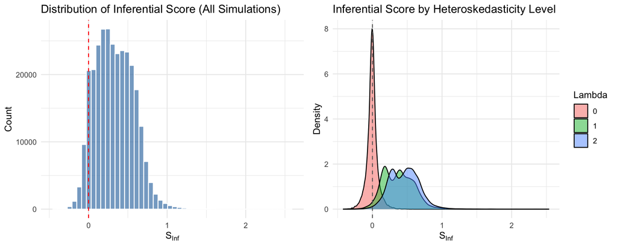

```r
# Use centralized plotting function from R/60_tables_and_plots.R
plot_sinf_distribution(hetero_sim_results, lambda_subset = c(0, 0.5, 1.0, 1.5, 2.0))
```

**Key Observations:** - Under the null ($\lambda = 0$), $S_{\mathrm{Inf}}$ is centered near zero. - As heteroskedasticity increases, $S_{\mathrm{Inf}}$ shifts positive (robust SE > classic SE). - The distribution widens with increasing $\lambda$, reflecting greater variability under misspecification.

# 5 Section 4: The Problem: N-Dependence of the Inferential Score

We now investigate whether the inferential score works as a severity measure or primarily as a test statistic. The scaled version:
$$T_{S_{\mathrm{Inf}}} = \sqrt{N} \cdot
S_{\mathrm{Inf}}$$
is approximately standard normal under homoskedasticity, so we can reject the null (homoskedasticity) if $T_{S_{\mathrm{Inf}}} > 1.645$.

## 5.1 4.1 Power Analysis

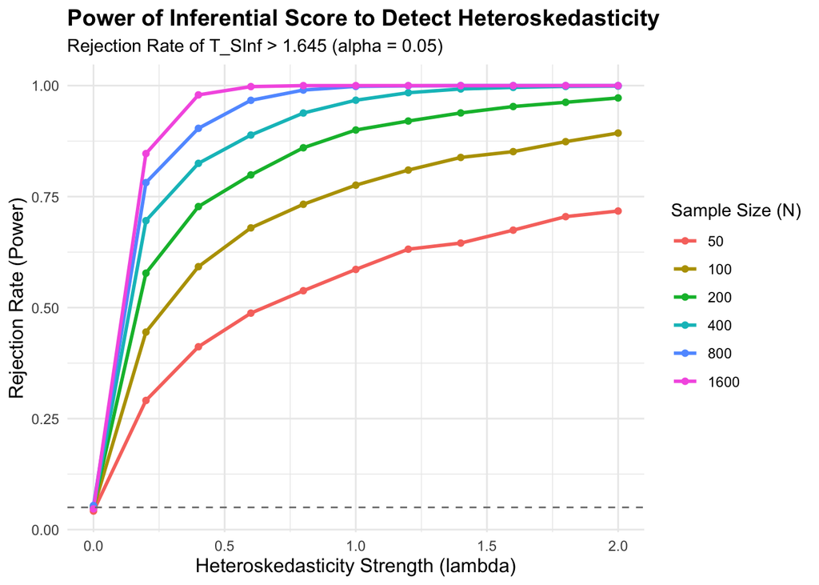

```r
# Compute T_SInf (which is sr_inf_adj in our nomenclature)
hetero_sim_results[, T_SInf := sr_inf_adj]

# Define rejection indicator
hetero_sim_results[, reject_null := as.integer(T_SInf > 1.645)]

# Aggregate rejection rates by N and hetero_strength (averaging over beta_x and sigma0)
power_summary <- hetero_sim_results[, .(
  rejection_rate = mean(reject_null)
), by = .(N, hetero_strength)]

# Use centralized plotting function from R/60_tables_and_plots.R
print(plot_power_curves(power_summary))
```

**Interpretation:** - **Null behavior**: When data is homoskedastic ($λ=0$), we reject erroneous ~5% of the time (good) - **Power**: As heteroskedasticity increases ($λ$ grows), we detect it more and more (expected) - **Sample size dependency**: For the same heteroskedasticity level, larger $N$ makes detection easier

This is perfect for a test statistic (higher power with larger samples), but problematic for a *severity measure* that should give the same reading regardless of $N$.

## 5.2 4.2 Formal Test of Parameter Effects (Multilevel ANOVA)

To formally establish which parameters affect $T_{S_{\mathrm{Inf}}}$, we fit a full factorial ANOVA with all experimental factors: sample size (N), heteroskedasticity strength (λ), effect size (β_x), and baseline noise (σ0).

**Note:** With ~300,000 observations, virtually all effects will be statistically significant ($p < 0.001$). We therefore focus on **effect sizes** (η², eta-squared) to assess practical significance: - η² < 0.01: negligible effect - η² ∈ [0.01, 0.06): small effect  
- η² ∈ [0.06, 0.14): medium effect - η² ≥ 0.14: large effect

```r
# Use RAW simulation data (not aggregated) to preserve within-cell variance
# Convert to factors for ANOVA
hetero_sim_results[, `:=`(
  N_factor = as.factor(N),
  lambda_factor = as.factor(hetero_strength),
  beta_factor = as.factor(beta_x),
  sigma_factor = as.factor(sigma0)
)]

# Fit full factorial ANOVA on raw data
# Note: With ~300k observations, p-values will all be < 0.001
# Focus on eta-squared for practical significance
anova_sinf_full <- aov(T_SInf ~ N_factor * lambda_factor * beta_factor * sigma_factor,
                       data = hetero_sim_results)
anova_summary_full <- summary(anova_sinf_full)

cat("Full Factorial ANOVA: T_SInf ~ N × λ × β_x × σ0\n")
```

```
## Full Factorial ANOVA: T_SInf ~ N × λ × β_x × σ0
```

```r
cat("=" |> rep(70) |> paste(collapse = ""), "\n")
cat(sprintf("Total observations: %d\n\n", nrow(hetero_sim_results)))
```

```
## Total observations: 297000
```

```r
# Compute eta-squared for each effect
ss_total <- sum(anova_summary_full[[1]]$`Sum Sq`)
anova_table <- anova_summary_full[[1]]
anova_table$eta_sq <- anova_table$`Sum Sq` / ss_total
anova_table$eta_sq_pct <- round(anova_table$eta_sq * 100, 2)

# Display results with effect sizes
cat("Effect Sizes (η² = Sum Sq / Total Sum Sq):\n")
```

```
## Effect Sizes (η² = Sum Sq / Total Sum Sq):
```

```r
cat("-" |> rep(70) |> paste(collapse = ""), "\n")
cat(sprintf("%-40s %12s %10s %10s\n", "Effect", "F value", "η²", "η² (%)"))
```

```
## Effect                                        F value       η²   η² (%)
```

```r
cat("-" |> rep(70) |> paste(collapse = ""), "\n")
for (i in 1:(nrow(anova_table) - 1)) {  # Exclude Residuals row
  effect_name <- rownames(anova_table)[i]
  f_val <- anova_table$`F value`[i]
  eta_sq <- anova_table$eta_sq[i]
  eta_pct <- anova_table$eta_sq_pct[i]

  # Effect size interpretation
  size_interp <- ifelse(eta_sq >= 0.14, "LARGE",
                        ifelse(eta_sq >= 0.06, "Medium",
                               ifelse(eta_sq >= 0.01, "Small", "Negligible")))

  cat(sprintf("%-40s %12.1f %10.4f %9.2f%%  [%s]\n",
              effect_name, f_val, eta_sq, eta_pct, size_interp))
}
```

```
## N_factor                                            284787.1     0.3943     39.43%  [LARGE]
## lambda_factor                                        62148.8     0.1721     17.21%  [LARGE]
## beta_factor                                              2.6     0.0000      0.00%  [Negligible]
## sigma_factor                                        340470.7     0.1886     18.86%  [LARGE]
## N_factor:lambda_factor                                4601.7     0.0637      6.37%  [Medium]
## N_factor:beta_factor                                     0.3     0.0000      0.00%  [Negligible]
## lambda_factor:beta_factor                                0.8     0.0000      0.00%  [Negligible]
## N_factor:sigma_factor                                24861.8     0.0688      6.88%  [Medium]
## lambda_factor:sigma_factor                            3998.1     0.0221      2.21%  [Small]
## beta_factor:sigma_factor                                 0.7     0.0000      0.00%  [Negligible]
## N_factor:lambda_factor:beta_factor                       1.1     0.0000      0.00%  [Negligible]
## N_factor:lambda_factor:sigma_factor                    291.8     0.0081      0.81%  [Negligible]
## N_factor:beta_factor:sigma_factor                        1.2     0.0000      0.00%  [Negligible]
## lambda_factor:beta_factor:sigma_factor                   0.9     0.0000      0.00%  [Negligible]
## N_factor:lambda_factor:beta_factor:sigma_factor          1.1     0.0001      0.01%  [Negligible]
```

```r
# Residuals
cat("-" |> rep(70) |> paste(collapse = ""), "\n")
resid_idx <- nrow(anova_table)
cat(sprintf("%-40s %12s %10.4f %9.2f%%\n",
            "Residuals", "-",
            anova_table$eta_sq[resid_idx],
            anova_table$eta_sq_pct[resid_idx]))
```

```
## Residuals                                           -     0.0821      8.21%
```

```r
# Extract key effects for interpretation (safely handle missing rows)
n_eta <- ifelse("N_factor" %in% rownames(anova_table),
                anova_table["N_factor", "eta_sq"], NA)
lambda_eta <- ifelse("lambda_factor" %in% rownames(anova_table),
                     anova_table["lambda_factor", "eta_sq"], NA)
n_lambda_eta <- ifelse("N_factor:lambda_factor" %in% rownames(anova_table),
                       anova_table["N_factor:lambda_factor", "eta_sq"], NA)

# Check for beta and sigma effects
beta_eta <- ifelse("beta_factor" %in% rownames(anova_table),
                   anova_table["beta_factor", "eta_sq"], NA)
sigma_eta <- ifelse("sigma_factor" %in% rownames(anova_table),
                    anova_table["sigma_factor", "eta_sq"], NA)

cat("\n\nKey Findings:\n")
cat("=" |> rep(50) |> paste(collapse = ""), "\n\n")

if (!is.na(n_eta)) {
  cat(sprintf("1. Sample Size (N):           η² = %.4f (%.1f%% of variance)\n",
              n_eta, n_eta * 100))
}
if (!is.na(lambda_eta)) {
  cat(sprintf("2. Heteroskedasticity (λ):    η² = %.4f (%.1f%% of variance)\n",
              lambda_eta, lambda_eta * 100))
}
if (!is.na(n_lambda_eta)) {
  cat(sprintf("3. N × λ Interaction:         η² = %.4f (%.1f%% of variance)\n",
              n_lambda_eta, n_lambda_eta * 100))
}

if (!is.na(beta_eta)) {
  cat(sprintf("4. Effect Size (β_x):         η² = %.4f (%.1f%% of variance)\n",
              beta_eta, beta_eta * 100))
}
if (!is.na(sigma_eta)) {
  cat(sprintf("5. Baseline Noise (σ0):       η² = %.4f (%.1f%% of variance)\n",
              sigma_eta, sigma_eta * 100))
}

cat("\n\nInterpretation:\n")
cat("-" |> rep(50) |> paste(collapse = ""), "\n")

if (!is.na(n_eta) && n_eta >= 0.01) {
  cat("→ N explains a meaningful portion of T_SInf variance.\n")
  cat("→ The inferential score is NOT sample-size invariant.\n")
}
if (!is.na(lambda_eta) && lambda_eta >= 0.06) {
  cat("→ λ has a substantial effect (as expected for a heteroskedasticity diagnostic).\n")
}
if (!is.na(n_lambda_eta) && n_lambda_eta >= 0.01) {
  cat("→ The N × λ interaction is meaningful: N-dependence varies with misspecification level.\n")
}
if (!is.na(beta_eta) && beta_eta < 0.01) {
  cat("→ Effect size (β_x) has negligible impact—score is effect-size invariant.\n")
}
if (!is.na(sigma_eta) && sigma_eta < 0.01) {
  cat("→ Baseline noise (σ0) has negligible impact—score is noise-level invariant.\n")
}

cat("\n→ CONCLUSION: T_SInf depends substantially on N, making it unsuitable\n")
cat("   as a direct measure of misspecification SEVERITY across sample sizes.\n")
```

Output: prints the eta-squared breakdown and interpretation for N-dependence.

## 5.3 4.3 Visualization of N-Dependence

Having established statistically significant N-dependence, we now visualize how $T_{S_{\mathrm{Inf}}}$ scales with sample size for fixed levels of heteroskedasticity.

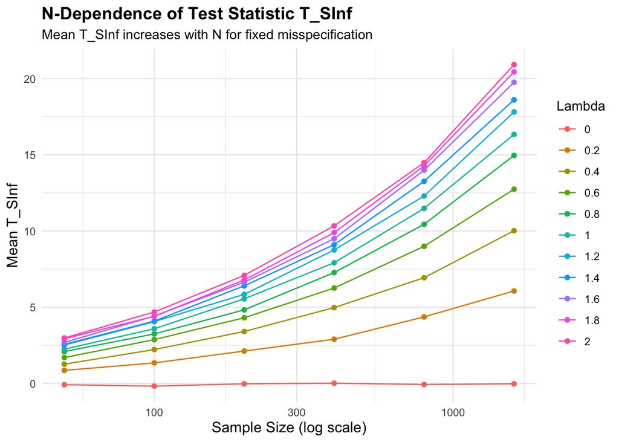

```r
# Subset to representative parameters (beta_x = 0.5, sigma0 = 1.0)
# Use ALL available lambda values from HETERO_STRENGTH_GRID (0, 0.2, 0.4, ..., 2.0)
subset_params <- hetero_sim_results[beta_x == 0.5 & sigma0 == 1.0]

# Aggregate mean T_SInf
sinf_n_summary <- subset_params[, .(
  mean_sinf = mean(sr_inf),
  mean_T_sinf = mean(T_SInf)
), by = .(N, hetero_strength)]

# Use centralized plotting function from R/60_tables_and_plots.R
print(plot_n_dependence(sinf_n_summary))
```

**Conclusion from Section 4:** $S_{\mathrm{Inf}}$ is a good *test statistic* (detects heteroskedasticity with high power), but a poor *severity measure* because it scales with $\sqrt{N}$. Two datasets with identical heteroskedasticity can give very different scores just because they have different sample sizes. We need something better.

# 6 Section 5: The Solution: Developing an N-Adjusted Reliability Score

Since the inferential score scales too much with $N$, we need a new metric that measures *severity* with reduced sample size dependence. This section develops the **reliability score**—a ratio-based alternative that corrects for finite-sample effects.

The strategy: 1. Start with the **raw SE ratio** (inverse of the inferential score) 2. Demonstrate it has much better N-stability than the inferential score 3. Add a small empirical correction for remaining finite-sample bias 4. Evaluate the degree to which the correction improves N-stability

## 6.1 5.0 The Raw Ratio: A Better Starting Point

We flip the inferential score upside down to get the **raw ratio**:
$$R =
\frac{\text{SE}_{\text{classic}}}{\text{SE}_{\text{robust}}}$$

Intuition: When HC2 is (correctly) widening the standard error due to heteroskedasticity, $R < 1$. The more heteroskedasticity, the smaller $R$ becomes. This ratio is bounded and interpretable as a severity measure.

```r
# Add ratio metrics post-hoc using the stored SE values
# sr_ratio = se_classic / se_robust (Raw Ratio)
hetero_sim_results[, sr_ratio := se_classic / se_robust]

cat("Raw Ratio (sr_ratio = SE_classic / SE_robust) Summary:\n")
```

```
## Raw Ratio (sr_ratio = SE_classic / SE_robust) Summary:
```

```r
print(summary(hetero_sim_results$sr_ratio))
```

```
##    Min. 1st Qu.  Median    Mean 3rd Qu.    Max.
##  0.2811  0.6646  0.7622  0.7786  0.8769  1.7336
```

## 6.2 5.1 Raw Ratio vs Inferential Score: N-Dependence Comparison

We first compare the N-dependence of the **Raw Ratio** against the **Inferential Score** established in Section 4.

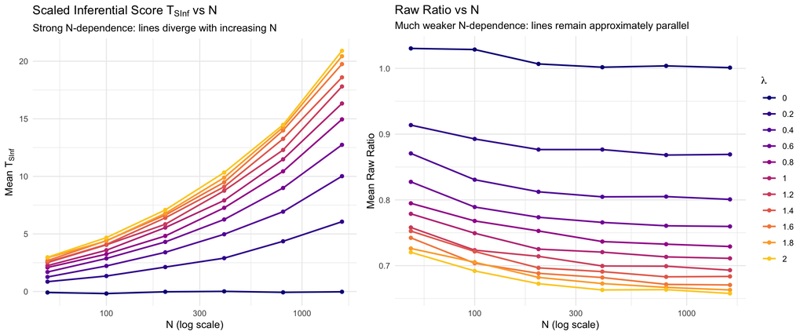

```r
# Use all lambda values for comprehensive comparison
subset_params <- hetero_sim_results[beta_x == 0.5 & sigma0 == 1.0]

# Aggregate both metrics
comparison_summary <- subset_params[, .(
  mean_T_sinf = mean(T_SInf),
  mean_sr_ratio = mean(sr_ratio)
), by = .(N, hetero_strength)]

# Use centralized plotting function from R/60_tables_and_plots.R
plot_tsinf_vs_ratio(comparison_summary)
```

## 6.3 5.2 Theoretical Basis for Finite-Sample Correction

The residual N-dependence in the Raw Ratio arises from the finite-sample behavior of HC2. Under the null hypothesis (homoskedasticity), the HC2 standard error exhibits finite-sample bias that partially scales with $1/\sqrt{N}$.

The Reliability Score applies a first-order correction to reduce (though not eliminate) this bias, improving cross-sample comparability.

## 6.4 5.3 Empirical Estimation of the Scaling Factor

We estimate the optimal scaling constant $c$ by regressing the Raw Ratio on $1/\sqrt{N}$ under the null ($\lambda = 0$).

```r
# Subset to null (lambda = 0) conditions only
null_data <- hetero_sim_results[hetero_strength == 0]

# Compute 1/sqrt(N)
null_data[, inv_sqrt_N := 1 / sqrt(N)]

# Regress raw ratio on 1/sqrt(N)
# sr_ratio = intercept + slope * (1/sqrt(N))
scaling_fit <- lm(sr_ratio ~ inv_sqrt_N, data = null_data)
scaling_summary <- summary(scaling_fit)

cat("Empirical Estimation of Scaling Factor\n")
```

```
## Empirical Estimation of Scaling Factor
```

```r
cat("=" |> rep(60) |> paste(collapse = ""), "\n\n")
cat("Model: sr_ratio = intercept + c * (1/sqrt(N))\n")
```

```
## Model: sr_ratio = intercept + c * (1/sqrt(N))
```

```r
cat("Under null (λ = 0), we expect intercept ≈ 1\n\n")
```

```
## Under null (λ = 0), we expect intercept ≈ 1
```

```r
intercept_est <- coef(scaling_fit)[1]
slope_est <- coef(scaling_fit)[2]
c_empirical <- slope_est

cat(sprintf("Intercept:           %.4f (expected: 1.0)\n", intercept_est))
```

```
## Intercept:           0.9928 (expected: 1.0)
```

```r
cat(sprintf("Slope (c):           %.4f\n", slope_est))
```

```
## Slope (c):           0.2382
```

```r
cat(sprintf("Empirical c:         %.4f\n", c_empirical))
```

```
## Empirical c:         0.2382
```

```r
cat(sprintf("\nR²:                  %.4f\n", scaling_summary$r.squared))
```

```
##
## R²:                  0.0138
```

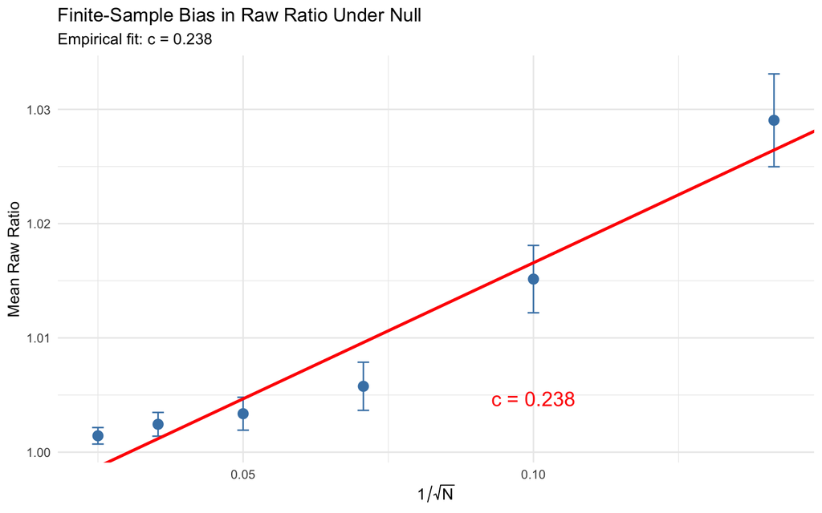

```r
# Aggregate null data by N for cleaner visualization
null_summary <- null_data[, .(
  mean_sr_ratio = mean(sr_ratio),
  se_sr_ratio = sd(sr_ratio) / sqrt(.N)
), by = N]
null_summary[, inv_sqrt_N := 1 / sqrt(N)]

# Use centralized plotting function from R/60_tables_and_plots.R
print(plot_finite_sample_bias(null_summary, intercept_est, slope_est))
```

## 6.5 5.4 Sensitivity Analysis: Effect of Model Complexity

1. **Canonical simple regression**: $Y = \beta_0 + \beta_1 X + \varepsilon$ (p = 2 parameters)
2. **Multiple regression with noise covariate**: $Y = \beta_0 + \beta_1 X + \beta_2 Z + \varepsilon$ (p = 3 parameters)

This sensitivity check determines whether our calibration on simple regression generalizes to more complex models.

```r
# Run sensitivity analysis using pipeline functions from R/10_dgp_and_fits.R
# Note: Global seed is set in R/00_config.R; parallel seeds handled via furrr_options(seed = TRUE)
N_test_grid <- c(50, 100, 200, 400, 800, 1600)
n_sims_test <- 10000

cat("Sensitivity Analysis: Effect of Model Complexity on Correction Factor\n")
```

```
## Sensitivity Analysis: Effect of Model Complexity on Correction Factor
```

```r
cat("=" |> rep(60) |> paste(collapse = ""), "\n")
cat(sprintf("Using pipeline functions: run_null_simulation_fast(), run_null_simulation_fast_multiple()\n"))
```

```
## Using pipeline functions: run_null_simulation_fast(), run_null_simulation_fast_multiple()
```

```r
cat(sprintf("Running %d simulations per N per model type\n\n", n_sims_test))
```

```
## Running 10000 simulations per N per model type
```

```r
# Use centralized pipeline function from R/10_dgp_and_fits.R
df_test_results <- run_sensitivity_analysis(
  N_grid = N_test_grid,
  n_sims = n_sims_test,
  hc_type = best_hc,
  verbose = TRUE
)
```

```
## Sensitivity Analysis: Simple vs Multiple Regression
##   N values: 50, 100, 200, 400, 800, 1600
##   Sims per N: 10000
##   HC type: HC2
##
##   Processing N = 50...
##   Processing N = 100...
##   Processing N = 200...
##   Processing N = 400...
##   Processing N = 800...
##   Processing N = 1600...
## Done.
```

```r
# Fit scaling factor for each model type
simple_fit <- lm(sr_ratio ~ inv_sqrt_N, data = df_test_results[model == "Simple (p=2)"])
multiple_fit <- lm(sr_ratio ~ inv_sqrt_N, data = df_test_results[model == "Multiple (p=3)"])

c_simple <- coef(simple_fit)[2]
c_multiple <- coef(multiple_fit)[2]
intercept_simple <- coef(simple_fit)[1]
intercept_multiple <- coef(multiple_fit)[1]

cat("Sensitivity Check: Effect of Model Complexity\n")
```

```
## Sensitivity Check: Effect of Model Complexity
```

```r
cat("=" |> rep(60) |> paste(collapse = ""), "\n\n")
cat("We compare the finite-sample bias correction factor (c) between:\n")
```

```
## We compare the finite-sample bias correction factor (c) between:
```

```r
cat("1. Canonical Simple Regression (p=2)\n")
```

```
## 1. Canonical Simple Regression (p=2)
```

```r
cat("2. Multiple Regression with Noise Covariate (p=3)\n\n")
```

```
## 2. Multiple Regression with Noise Covariate (p=3)
```

```r
cat(sprintf("%-25s %12s %12s\n", "Model", "Empirical c", "R²"))
```

```
## Model                      Empirical c          R²
```

```r
cat("-" |> rep(50) |> paste(collapse = ""), "\n")
cat(sprintf("%-25s %12.4f %12.4f\n",
            "Simple (y ~ x, p=2)",
            c_simple, summary(simple_fit)$r.squared))
```

```
## Simple (y ~ x, p=2)             0.2259       0.0123
```

```r
cat(sprintf("%-25s %12.4f %12.4f\n",
            "Multiple (y ~ x + z, p=3)",
            c_multiple, summary(multiple_fit)$r.squared))
```

```
## Multiple (y ~ x + z, p=3)       0.2207       0.0121
```

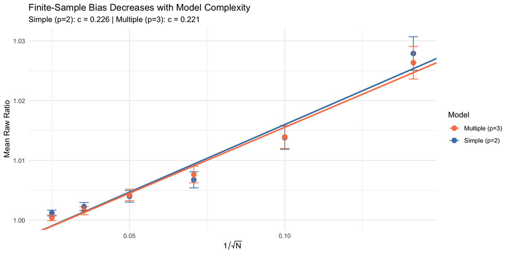

```r
# Aggregate by N and model
df_summary <- df_test_results[, .(
  mean_sr_ratio = mean(sr_ratio),
  se_sr_ratio = sd(sr_ratio) / sqrt(.N)
), by = .(N, model, inv_sqrt_N)]

# Use centralized plotting function from R/60_tables_and_plots.R
print(plot_sensitivity_comparison(df_summary, c_simple, c_multiple,
                                   intercept_simple, intercept_multiple))
```

```r
cat("\nConclusion: Simple Regression Calibration is Conservative\n")
```

```
##
## Conclusion: Simple Regression Calibration is Conservative
```

```r
cat("=" |> rep(60) |> paste(collapse = ""), "\n\n")
cat("Adding covariates REDUCES the finite-sample bias:\n")
```

```
## Adding covariates REDUCES the finite-sample bias:
```

```r
cat(sprintf("  Simple regression (p=2):   c = %.4f\n", c_simple))
```

```
##   Simple regression (p=2):   c = 0.2259
```

```r
cat(sprintf("  Multiple regression (p=3): c = %.4f\n", c_multiple))
```

```
##   Multiple regression (p=3): c = 0.2207
```

```r
cat(sprintf("  Reduction:                 %.1f%%\n\n", (c_simple - c_multiple) / c_simple * 100))
```

```
##   Reduction:                 2.3%
```

```r
cat("Implication:\n")
```

```
## Implication:
```

```r
cat("-" |> rep(50) |> paste(collapse = ""), "\n")
cat("Calibrating the Reliability Score on simple regression (c ≈ 0.25)\n")
```

[output not shown]

```r
cat("provides a CONSERVATIVE correction. For models with additional covariates,\n")
```

```
## provides a CONSERVATIVE correction. For models with additional covariates,
```

```r
cat("the correction slightly over-adjusts, ensuring the metric remains safe\n")
```

```
## the correction slightly over-adjusts, ensuring the metric remains safe
```

```r
cat("(i.e., it will not underestimate reliability issues).\n\n")
```

```
## (i.e., it will not underestimate reliability issues).
```

```r
cat(sprintf("We adopt c = %.4f from the simple regression calibration.\n", c_empirical))
```

```
## We adopt c = 0.2382 from the simple regression calibration.
```

```r
cat("\nNote: This provides a conservative finite-sample correction, though complete\n")
```

```
##
## Note: This provides a conservative finite-sample correction, though complete
```

```r
cat("N-invariance is not achieved, suggesting higher-order terms may be present.\n")
```

```
## N-invariance is not achieved, suggesting higher-order terms may be present.
```

## 6.6 5.6 Comparison of Scaling Factors for N-Stability

We now compare the raw ratio against the empirically-adjusted ratio using our calibrated constant derived from the simple regression case:

1. **Raw Ratio** (no correction): $R = \text{SE}_{\text{classic}} / \text{SE}_{\text{robust}}$
2. **Empirical correction** (Reliability Score): $S_{\mathrm{Rel}} = R - c/\sqrt{N}$

```r
# Safety Check: Ensure c_empirical is defined from Section 5.3
if (!exists("c_empirical")) stop("c_empirical is missing! Run Section 5.3 first.")

# Compute adjusted ratio using the conservative empirical constant
hetero_sim_results[, sr_ratio_adj := sr_ratio - c_empirical / sqrt(N)]

# Aggregate by N and lambda
scaling_comparison <- hetero_sim_results[, .(
  mean_raw = mean(sr_ratio),
  mean_adjusted = mean(sr_ratio_adj)
), by = .(N, hetero_strength)]

# Compute spread (max - min across N) for each lambda and metric
spread_by_lambda <- scaling_comparison[, .(
  spread_raw = max(mean_raw) - min(mean_raw),
  spread_adjusted = max(mean_adjusted) - min(mean_adjusted)
), by = hetero_strength]

cat("N-Invariance Comparison: Spread (max - min) Across Sample Sizes\n")
```

```
## N-Invariance Comparison: Spread (max - min) Across Sample Sizes
```

```r
cat("=" |> rep(60) |> paste(collapse = ""), "\n\n")
cat(sprintf("Using conservative scaling factor c = %.4f\n\n", c_empirical))
```

```
## Using conservative scaling factor c = 0.2382
```

```r
cat(sprintf("%-10s %15s %15s\n", "Lambda", "Raw Ratio", "Adjusted (S_Rel)"))
```

```
## Lambda           Raw Ratio Adjusted (S_Rel)
```

```r
cat("-" |> rep(60) |> paste(collapse = ""), "\n")
for (i in 1:nrow(spread_by_lambda)) {
  cat(sprintf("%-10.1f %15.4f %15.4f\n",
              spread_by_lambda$hetero_strength[i],
              spread_by_lambda$spread_raw[i],
              spread_by_lambda$spread_adjusted[i]))
}
```

```
## 0.0                 0.0276          0.0066
## 0.2                 0.0481          0.0214
## 0.4                 0.0564          0.0290
## 0.6                 0.0562          0.0288
## 0.8                 0.0598          0.0325
## 1.0                 0.0615          0.0345
## 1.2                 0.0593          0.0315
## 1.4                 0.0629          0.0362
## 1.6                 0.0626          0.0349
## 1.8                 0.0611          0.0334
## 2.0                 0.0636          0.0359
```

```r
# Summary statistics
cat("\n")
```

```r
cat("-" |> rep(60) |> paste(collapse = ""), "\n")
cat(sprintf("%-10s %15.4f %15.4f\n", "Mean",
            mean(spread_by_lambda$spread_raw),
            mean(spread_by_lambda$spread_adjusted)))
```

```
## Mean                0.0563          0.0295
```

```r
# Improvement
improvement <- (mean(spread_by_lambda$spread_raw) - mean(spread_by_lambda$spread_adjusted)) /
               mean(spread_by_lambda$spread_raw) * 100
cat(sprintf("\nImprovement in mean spread: %.1f%%\n", improvement))
```

```
##
## Improvement in mean spread: 47.6%
```

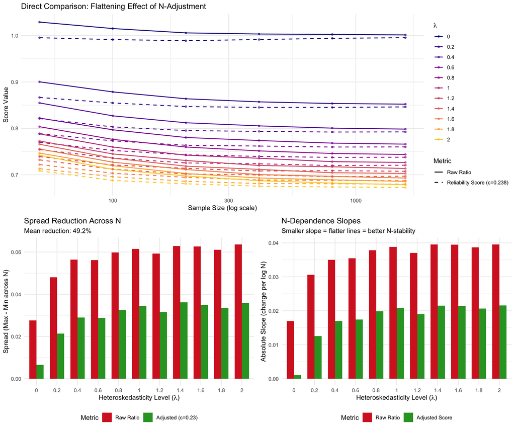

```r
# Melt for plotting
scaling_long <- melt(scaling_comparison,
                     id.vars = c("N", "hetero_strength"),
                     measure.vars = c("mean_raw", "mean_adjusted"),
                     variable.name = "Metric", value.name = "Value")

# Convert to data.table if not already
scaling_long <- as.data.table(scaling_long)

scaling_long[, Metric := factor(Metric,
                                levels = c("mean_raw", "mean_adjusted"),
                                labels = c("Raw Ratio",
                                          sprintf("Reliability Score (c=%.3f)", c_empirical)))]

# Use centralized plotting function from R/60_tables_and_plots.R
# This creates a 3-panel visualization showing:
# 1. Overlaid comparison (top) - shows flattening effect directly
# 2. Spread reduction by lambda (bottom left) - quantifies improvement
# 3. Slope comparison (bottom right) - shows reduced N-dependence
plot_scaling_comparison(scaling_long)
```

We formally test N-dependence for each metric. We expect the N-Effect ($\eta^2$) to be substantially reduced (though not eliminated) for the Reliability Score.

```r
# ANOVA on Reliability Score to verify N-invariance
# Note: This is computationally expensive with ~300k observations
cat("Computing ANOVA for Reliability Score N-dependence...\n")
```

```
## Computing ANOVA for Reliability Score N-dependence...
```

```r
anova_adj <- aov(sr_ratio_adj ~ N_factor + lambda_factor,
                 data = hetero_sim_results)
ss_adj <- summary(anova_adj)[[1]]
ss_total_adj <- sum(ss_adj$`Sum Sq`)
n_eta_adj <- ifelse("N_factor" %in% rownames(ss_adj),
                    ss_adj["N_factor", "Sum Sq"] / ss_total_adj, NA)
lambda_eta_adj <- ifelse("lambda_factor" %in% rownames(ss_adj),
                         ss_adj["lambda_factor", "Sum Sq"] / ss_total_adj, NA)

cat("\nANOVA Effect Size for Reliability Score\n")
```

```
##
## ANOVA Effect Size for Reliability Score
```

```r
cat("=" |> rep(60) |> paste(collapse = ""), "\n\n")
cat(sprintf("%-30s %12s\n", "Factor", "η²"))
```

```
## Factor                                 η²
```

```r
cat("-" |> rep(60) |> paste(collapse = ""), "\n")
if (!is.na(n_eta_adj)) {
  cat(sprintf("%-30s %11.4f%%\n", "Sample Size (N)", n_eta_adj * 100))
} else {
  cat(sprintf("%-30s %11s\n", "Sample Size (N)", "[see warning]"))
}
```

```
## Sample Size (N)                [see warning]
```

```r
if (!is.na(lambda_eta_adj)) {
  cat(sprintf("%-30s %11.4f%%\n", "Heteroskedasticity (λ)", lambda_eta_adj * 100))
}
```

```
## Heteroskedasticity (λ)            37.7866%
```

```r
cat("\n")
```

```r
if (!is.na(n_eta_adj) && n_eta_adj < 0.01) {
  cat("✓ The Reliability Score substantially reduces N-dependence (η² < 1%).\n")
  cat(sprintf("  The correction (c = %.3f) provides substantial improvement over raw ratio.\n", c_empirical))
} else if (!is.na(n_eta_adj) && n_eta_adj < 0.06) {
  cat("✓ Reliability Score N-effect is reduced to SMALL (η² < 6%).\n")
  cat(sprintf("  The correction (c = %.3f) reduces but does not eliminate N-dependence.\n", c_empirical))
} else {
  cat("⚠ Warning: N-effect remains noticeable (η² ≥ 6%).\n")
  cat(sprintf("  The correction (c = %.3f) provides partial improvement.\n", c_empirical))
}
```

```
## ⚠ Warning: N-effect remains noticeable (η² ≥ 6%).
##   The correction (c = 0.238) provides partial improvement.
```

## 6.8 5.8 Classical Coverage Degradation

We visualize how classical CI coverage degrades with increasing heteroskedasticity. This motivates using the Reliability Score to map to coverage loss.

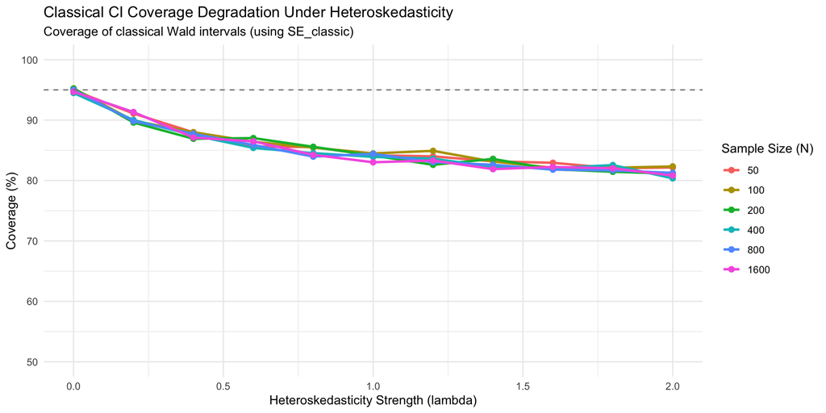

```r
# Aggregate coverage by N and hetero_strength
coverage_summary <- hetero_sim_results[, .(
  mean_coverage = mean(coverage) * 100,
  se_coverage = sd(coverage) / sqrt(.N) * 100
), by = .(N, hetero_strength)]

# Use centralized plotting function from R/60_tables_and_plots.R
print(plot_coverage_degradation(coverage_summary))
```

**Key Observation:** Classical coverage degrades systematically with heteroskedasticity. The Reliability Score $S_{\mathrm{Rel}}$ exhibits improved N-stability compared to $S_{\mathrm{Inf}}$, though complete N-invariance is not achieved. This makes it more suitable for comparing heteroskedasticity severity across different sample sizes.

# 7 Summary

This notebook completed the validation pipeline using heteroskedastic data. Here’s what we found:

## 7.1 Key Results

1. **S_Inf is a test statistic, not a severity score**
- $T_{S_{\mathrm{Inf}}}$ increases with sample size even when heteroskedasticity is fixed
- Eta-squared results show N explains nontrivial variance, so S_Inf is not comparable across datasets
2. **Reliability Score substantially reduces N-dependence**
   $$S_{\mathrm{Rel}} =
   \frac{\mathrm{SE}_{\text{classic}}}{\mathrm{SE}_{\text{robust}}} -
   \frac{c}{\sqrt{N}}$$
- Estimated correction factor: $c \approx 0.23$ (simple regression calibration)
- The adjustment improves N-stability (47.6% reduction in spread) but does not achieve complete invariance
- Remaining N-dependence suggests additional finite-sample effects beyond the 1/√N correction
3. **Coverage falls with heteroskedasticity**
- Classical confidence interval coverage declines as $\lambda$ increases
- The Reliability Score tracks this deterioration and provides a practical severity metric

## 7.2 Reproducibility

- All random seeds configured in `R/00_config.R`
- All results saved to `results/` directory
- Run Parts 1–2 in sequence for complete reproducibility
- Complete dataset reproducible by re-running this notebook with identical seed and configuration.